[figure not shown]

# NLP, Deep Learning, Graph Visualization and Analytics

Neo4j and GraphXR working together to survey 30,000 dream journals from [UCSC’s DreamBank](http://dreambank.net/)

- Connect similar dreams in a Dream Similarity Graph
- Extract Named Entities for dream interpretation
- Use a community detection algorithm to find dream clusters
- Text-to-image generation based on a dream's first sentence
- Inject dreamers, dreams and entities and their relationships into Neo4j
- Use GraphXR for analysis and visualization

[figure not shown]

# Shared Dreams in a Dream Similarity Graph

To build the Dream Similarity Graph we captured the vector representation of each dream using a Gensim Doc2Vec model trained on the dream content.

We gage how similar two dreams are by their cosine similarity.

The pairwise similarity score across all dreams builds a K-nearest neighbors graph where each node is a dream connected to the k most similar dreams with a similarity score above a threshold.

This GraphXR view below shows dreams for the dreamer “UCSC_women” connected to similar dreams across other dreamers. The visualization evokes a dream catcher and shows which dreamers UCSC_women have the most dreams in common with. Click on the image to interact with the GraphXR view.

[figure not shown]

# Dream Interpretation with Named Entity Recognition

Using SpaCy Named Entity Recognition to tease out mentions of people, organizations, locations, dates and other informative categories. In this way, we build a topical, high-level view of individual dreamers or dream clusters.

This GraphXR view shows all dreams for the dreamer “jasmine4” and the people and places most frequently mentioned. Jasmine4’s dreams are arrayed in a circle in order of date dreamt and entity node size is a function of frequency of mentions across dreams. This allows us to see how the main topics of her dreams evolve across time. Click on the image to interact with the GraphXR view.

[figure not shown]

# Using Community Detection for Dream Clusters and Text-to-image Generation for Dream Snapshots

This GraphXR view shows a dream cluster related to sports. If you hover over the dream nodes you can see the beginning sentences of the dream that were fed to the Aleph Delta neural network to generate the resulting dream snapshot. Click on the image to interact with the GraphXR view.

[figure not shown]

# Loading 30,000 dream reports

[figure not shown]

Luckily, Matt Bierner scraped all dreams and made them available as json files in his github, which you can download directly.

```python
!git clone -q https://github.com/mattbierner/DreamScrape.git ../
```

```python
import os
import json
import pandas as pd
import numpy as np

dreamers=os.listdir("../DreamScrape/dreams")
dreamers
```

```
['phil1.json',
 'phil2.json',
 'jasmine4.json',
 'seventh_graders.json',
 'jeff.json',
 'vonuslar.de.json',
 'pegasus.json',
 'jasmine3.json',
 'miami-home.json',
 'jasmine2.json',
 'madeline4-postgrad.json',
 'bosnak.json',
 'physiologist.json',
 'david.json',
 'ed.json',
 'peru-f.json',
 'wedding.json',
 'ringo.json',
 'vietnam_vet2.json',
 'zurich-f.de.json',
 'b2.json',
 'ucsc_women.json',
 'toby.json',
 'esther.json',
 'edna.json',
 'midwest_teens-m.json',
 'zurich-m.de.json',
 'bay_area_girls_789.json',
 'chris.json',
 'norms-m.json',
 'miami-lab.json',
 'mack.json',
 'german-f.de.json',
 'norms-f.json',
 'nancy.json',
 'melora.json',
 'madeline1-hs.json',
 'peru-m.json',
 'emma.json',
 'phil3.json',
```

[output cut: 20 more lines]

```
 'b.json',
 'dorothea.json',
 'vietnam_vet.json',
 'samantha.json',
 'dahlia.json',
 'alta.json',
 'vickie.json',
 'lawrence.json',
 'merri.json',
 'bay_area_girls_456.json',
 'emmas_husband.json',
 'blind-m.json',
 'hall_female.json',
 'arlie.json',
 'angie.json']
```

Here's what one json dream file looks like:

```python
with open("../DreamScrape/dreams/phil1.json") as the_file:
    js=json.load(the_file)

js
```

```
{'dreamer': 'phil1',
 'description': 'Phil 1: teens',
 'dreams': [{'number': '1-001',
   'head': '1957-08-05',
   'content': "Uncle Albert is getting ready to leave for a vacation and is taking me along.  I don't want to go, and I tell Uncle Albert that someone is coming by to get me at 11:00 a.m., but it makes no difference.  Someone does finally come by for me, though:  Uncle Joe.  On the way home (or wher…
  {'number': '1-002',
   'head': '1957-08-06',
   'content': "I go to a ball game with Uncle Ben and Aunt Aimee.  The ball park has lights, stands, very short but high wooden fences.  McAddo High is playing.  As I am standing by the bench, Coach Bowles tells me to play center field.  This means I may get to bat this inning.  The coach gives me d…
  {'number': '1-003',
   'head': '1957-08-07',
   'content': 'Rover (our dog) has to be shot.  I am appointed to do it, but I just cannot bring myself to do it when he stares into the barrel of the gun so peacefully.  Grandpa finally has to do it.  I cry a while and then wake up, greatly relieved to know that it was just a dream.  After I go bac…
  {'number': '1-004',
   'head': '1957-08-08',
   'content': "We are in Grandpa's car.  Grandpa is driving.  We strike and kill five different people.  I remember the last one well, because I saw a group of children in the road in the middle of the road-a pair of twins and another child, all about 4 years old.  Grandpa tried to straddle them wit…
  {'number': '1-005',
   'head': '1957-08-08',
   'content': 'Something about Sue Henderson standing by some swimming pool naked.'},
  {'number': '1-006',
   'head': '1957-08-09',
   'content': 'I am on some sort of high structure such as a not-quite-finished skyscraper, with some other boys, among them Ricky Adams.  I am without fear of falling.  We lean over the side, hanging on to each other.'},
  {'number': '1-007',
   'head': '1957-08-09',
   'content': "A croquet game is being played--at Grandpa's house, it seems, although the court is much, much bigger than his.  It is so wide and thick with grass that with all my power I cannot strike a ball across it.  There are also numerous obstacles such as shooting around a corner when you com…
  {'number': '1-008',
   'head': '1957-08-11',
   'content': 'Patty has Jerry Bardo\'s picture on her wall.  I ask her if she knows him, and she says, well, she knows his brother.  It seems that Patty and a girl friend of hers double dated with Jerry and his brother, and she didn\'t think much of either one of them.  "The pretty bad type," she s…
  {'number': '1-009',
   'head': '1957-08-12',
   'content': 'Doug and I go to see The Thing, but shown by a home projector, not at a movie theater.  A lot of kids are there, including one girl I especially notice.  She is real cute and has long, sandy hair.  When the monster comes on the screen, I hide my face so that I won\'t have bad dreams. …
  {'number': '1-010',
   'head': '1957-08-13',
   'content': 'I am with Patty, Doug, Jimmy Creagar and Jimmy Duggan, and possibly others, in Ciudad Juarez, Mexico.  We go through some sort of house-type museum.  There is a lady upstairs who doesn\'t seem to like me, and when we come downstairs I look up just in time to see two metal ornaments wh…
  {'number': '1-011',
   'head': '1957-08-13',
   'content': 'I am in back of Lark School in my hometown and there are all kinds of kids and coaches from my hometown schools playing football or baseball.  Some were from McAddo High, judging from the colors they wore.  I saw Wally White and asked him if he had been to Juarez and seen the "pee-pee…
  {'number': '1-012',
   'head': '1957-08-14',
   'content': "I am coming from someone's house on the bus in my hometown at night.  I get off downtown.  I go to the post office, where I see Jackie Levis first, and then Pat Byers.  Pat is wearing a red dress.  I realize that we have broken up, and I calmly tell her hello.  She is very friendly an…
  {'number': '1-013',
   'head': '1957-08-15',
```

[output cut: 264 more lines]

```
  {'number': '1-102',
   'head': '1959-10-11',
   'content': 'All of my family, including Daddy, were downtown looking for something, in the 700 block of Crescent City.  I knew Daddy was going to die, and I kept telling him he had better quit walking.  We went by a movie theater where "The Nun\'s Story" was playing.  Mother said she would like t…
  {'number': '1-103',
   'head': '1959-10-11',
   'content': 'I was going to take Hillary on a plane ride.  It was at night, and the plane was hovering like a helicopter, about three feet from the ground, and revolving.  I had to bend down so as not to get hit by the propeller, wheels, etc., and could not get close enough to board.'},
  {'number': '1-104',
   'head': '1959-11-01',
   'content': "I was in some garage, and there were two bears after me.  I tried swimming across something there, but one of them swam after me.  Even when I climbed up on a ledge, they could still just touch my feet.  I threw a small steel ball at one but missed.  I had a revolver in my hand, and t…
  {'number': '1-105',
   'head': '1959-11-02',
   'content': 'There was something like a basement full of water, the entrance to which was very narrow, and you could only squeeze through on your belly.  Randy Creagar and his dad were there, and so was Judson Schinn.  I saw some fish swimming around and decided to go above and try to get a knife …
  {'number': '1-106',
   'head': '1959-11-02',
   'content': 'There was a small frame house, the kitchen door just inside and to the left of the front door.  Jim Nudd was inside.  Somehow the house caught on fire, in the kitchen.  Jim came to the kitchen door and was nearly hysterical with amazement.  "Good Lord." he kept saying, "what a terribl…
```

We're going to transform these separate json files into one pandas dataframe.

```python
df=pd.DataFrame()
for dr in dreamers:
    with open('../DreamScrape/dreams/'+dr) as json_file:
        jsn=json.load(json_file)
        d=pd.DataFrame(jsn['dreams'])
        d['dreamer']=jsn['dreamer']
        d['description']=jsn['description']
        df=df.append(d)

df.index=range(len(df))
```

```python
df.head()
```

|  | number | head | content | dreamer | description |
| --- | --- | --- | --- | --- | --- |
| 0 | 1-001 | 1957-08-05 | Uncle Albert is getting ready to leave for a v... | phil1 | Phil 1: teens |
| 1 | 1-002 | 1957-08-06 | I go to a ball game with Uncle Ben and Aunt Ai... | phil1 | Phil 1: teens |
| 2 | 1-003 | 1957-08-07 | Rover (our dog) has to be shot. I am appointe... | phil1 | Phil 1: teens |
| 3 | 1-004 | 1957-08-08 | We are in Grandpa's car. Grandpa is driving. ... | phil1 | Phil 1: teens |
| 4 | 1-005 | 1957-08-08 | Something about Sue Henderson standing by some... | phil1 | Phil 1: teens |

Who are our dreamers? Who are the most prolific dreamers? Our least?

```python
df.groupby(['dreamer', 'description'])['content'].count().sort_values(ascending=False)
```

```
dreamer      description
vonuslar.de  Detlev von Uslar, auf Deutsch       6094
b            Barb Sanders                        3114
kenneth      Kenneth                             2021
elizabeth    Elizabeth: a woman in her 40s       1707
norman       Norman: a child molester            1235
                                                 ...
tom          Tom: An outgoing man                  27
dahlia       Dahlia: concerns with appearance      24
mark         Mark: a young boy                     23
edna         Edna: a blind woman                   19
ringo        Ringo: from the 1960s                 16
Name: content, Length: 74, dtype: int64
```

```python
df.idx.nunique()
```

```
22415
```

```python
df.dreamer.nunique()
```

```
69
```

# Dream embeddings and building a Dream Similarity Graph

To start with, we capture the vector representation of each dream using a Gensim Doc2Vec model trained on the dream content. We gauge how similar two dreams are by their cosine similarity.

## What is Doc2Vec?

Vector representation of text evolved from Bag-of-Words representation to Word2Vec to Doc2Vec. From [Distributed Representations of Sentences and Documents](https://cs.stanford.edu/~quocle/paragraph_vector.pdf) paper or this great explanation in [this medium post](https://medium.com/wisio/a-gentle-introduction-to-doc2vec-db3e8c0cce5e)!

[figure not shown]

We preprocess the data by removing stop words and tokenizing.

```python
import gensim
from gensim.parsing.preprocessing import remove_stopwords

def preprocess(df):
    for row in df.iterrows():
        filtered=remove_stopwords(row[1]['content'])
        tokens = gensim.utils.simple_preprocess(filtered)
        yield gensim.models.doc2vec.TaggedDocument(tokens, [row[0]])
```

This is what the first dream looks like once pre-processed.

```python
list(preprocess(df.loc[:0,]))
```

```
[TaggedDocument(words=['uncle', 'albert', 'getting', 'ready', 'leave', 'vacation', 'taking', 'along', 'don', 'want', 'go', 'tell', 'uncle', 'albert', 'coming', 'makes', 'difference', 'someone', 'finally', 'come', 'me', 'though', 'uncle', 'joe', 'on', 'way', 'home', 'or', 'going', 'stop', 'old', 'sch…
```

Preprocessing the entire dataframe:

```python
train_corpus=list(preprocess(df))
```

```python
model = gensim.models.doc2vec.Doc2Vec(vector_size=55, min_count=10, epochs=40)
model.build_vocab(train_corpus)
model.train(train_corpus, total_examples=model.corpus_count, epochs=model.epochs)

model.save("dreams-doc2vec-model")
```

Typically, the angle between two vectors is used as a measure of divergence between the vectors, and cosine of the angle has the nice property that it is 1.0 for identical vectors and 0.0 for orthogonal vectors.[[1]](http://singhal.info/ieee2001.pdf)

[figure not shown]

We build a function to get index position and the similarity score for the n most similar dreams.

```python
def get_most_similar(text,n=3):
    filtered=remove_stopwords(text)
    tokens = gensim.utils.simple_preprocess(filtered)
    vector = model.infer_vector(tokens)
    sims = model.docvecs.most_similar([vector])
    return [i for i in sims[:n]]

get_most_similar(df['content'][0],5)
```

```
[(0, 0.9664840698242188),
 (17754, 0.5446972846984863),
 (24678, 0.5409103631973267),
 (28, 0.5126920342445374),
 (26535, 0.5066430568695068)]
```

You can see that in this case, the most similar dream to dream at index position 0 is itself with score 0.96, so from now on we discard the most similar dream.

For each dream, let's add the indices and scores for the 9 most similar dreams to it. Let's also take a look at the distribution of similarity scores so that we can decide which threshold to use to connect our dreams in our dream similarity graph.

```python
df['neighbors']=df['content'].apply(lambda x: get_most_similar(x,n=10)[1:])
```

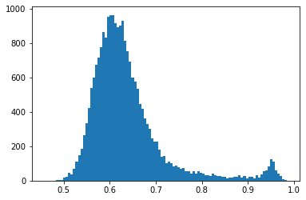

```python
plt.hist([x[0][1] for x in df['neighbors']], bins=100)
plt.show()
```

We can see that for the second most similar dreams, most scores are above 0.6.

This is the score distribution for the 9th most similar dream.

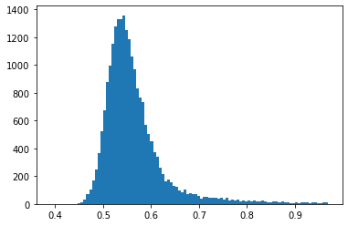

```python
matplotlib.pyplot.hist([x[8][1] for x in df['neighbors']], bins=100)
plt.show()
```

In the case of the 9th most similar dream, most scores are below 0.6. So let's use 0.6 as the threshold above which we will connect two dreams in our dream similarity graph.

# Extracting entities with spaCy

[spaCy](https://spacy.io/api/entityrecognizer) allows us to load a pre-trained model in order to identify a variety of named and numeric entities, including companies, locations, organizations and products.

[figure not shown]

```python
import spacy
nlp = spacy.load("en_core_web_sm")
```

```python
mylist=[]
for idx, row in df.iterrows():
    doc=nlp(row['content'])
    if doc.ents:
        for ent in doc.ents:
            mylist.append((ent.text,ent.label_,row['idx']))
```

```python
ent_df=pd.DataFrame(mylist)
ent_df.columns=['text', 'entity_type','idx']
ent_df.head()
```

|  | text | entity_type | idx |
| --- | --- | --- | --- |
| 0 | Uncle Albert | PERSON | 0-1-001 |
| 1 | Albert | PERSON | 0-1-001 |
| 2 | 11:00 a.m. | TIME | 0-1-001 |
| 3 | Joe | PERSON | 0-1-001 |
| 4 | 2 | CARDINAL | 0-1-001 |

```python
g=ent_df.groupby(['text','entity_type','idx'])['idx'].count()
g=g.reset_index(level='entity_type')
g.columns=['entity_type','count']
g=g.reset_index()
```

```python
g.head(3)
```

|  | text | idx | entity_type | count |
| --- | --- | --- | --- | --- |
| 0 | " - Tree | 59-362 | WORK_OF_ART | 1 |
| 1 | " George of Seinfeld | 17-3274 | WORK_OF_ART | 1 |
| 2 | "Ba Ba | 42-497 | PERSON | 1 |

```python
len(g)
```

```
79231
```

```python
g.entity_type.value_counts()
```

```
PERSON         23793
CARDINAL       18641
ORG             7198
DATE            6841
GPE             5073
ORDINAL         4383
TIME            4314
NORP            2200
QUANTITY        1560
MONEY           1394
FAC             1085
LOC              920
WORK_OF_ART      908
PRODUCT          355
LANGUAGE         306
EVENT            155
PERCENT           60
LAW               45
Name: entity_type, dtype: int64
```

# Load dreams into Neo4j database running on Docker

This is a simple bash script that spins up a Neo4j Docker container and installs the apoc and Graph Data Science libraries.

[figure not shown]

Then we can upload the data into Neo4j via Python.

```python
from py2neo import  Graph, Node

graphdb = Graph(scheme="bolt", host="localhost", port=7687, secure=False,
                auth=('neo4j', 'test'))
```

## Create constraints

```python
# creating constraints
query="""CREATE CONSTRAINT ON (d:Dreamer) ASSERT d.name IS UNIQUE"""
graphdb.run(query)
```

```
<py2neo.database.Cursor at 0x7f06345c59d0>
```

```python
query="""CREATE CONSTRAINT ON (d:Dream) ASSERT d.idx IS UNIQUE"""
graphdb.run(query)
```

```
<py2neo.database.Cursor at 0x7f06345dc410>
```

```python
query="""CREATE CONSTRAINT ON (d:Entity) ASSERT d.id IS UNIQUE"""
graphdb.run(query)
```

```
<py2neo.database.Cursor at 0x7f063677d190>
```

# Creating Dreamer nodes

```python
# Dreamer nodes
d=df[['dreamer','description']]
d=d.drop_duplicates()
d.head(3)
```

|  | dreamer | description |
| --- | --- | --- |
| 0 | phil1 | Phil 1: teens |
| 106 | phil2 | Phil 2: late 20s |
| 326 | jasmine4 | Jasmine 4: college 2 |

```python
dreamers=[{"name": x[1]['dreamer'],
 "description": x[1]['description']} for x in d.iterrows()]
```

```python
dreamers[0:5]
```

```
[{'name': 'phil1', 'description': 'Phil 1: teens'},
 {'name': 'phil2', 'description': 'Phil 2: late 20s'},
 {'name': 'jasmine4', 'description': 'Jasmine 4: college 2'},
 {'name': 'seventh_graders', 'description': 'Seventh grade girls'},
 {'name': 'jeff', 'description': 'Jeff: a lucid dreamer'}]
```

```python
query = """
    UNWIND $dreamers AS dreamer
    MERGE (d:Dreamer {name: dreamer.name, description: dreamer.description})"""
graphdb.run(query, {"dreamers":dreamers})
```

```
<py2neo.database.Cursor at 0x7f0646cf1710>
```

# Creating Dream nodes and connecting them to Dreamers with the DREAMT_BY relationship

```python
dreams=[{"dreamer": x[1]['dreamer'],
         "content": x[1]['content'],
        "date": x[1]['head'] ,
        "number": x[1]['number'],
        "idx":x[1]['idx']} for x in df.iterrows()]
```

```python
dreams[0]
```

```
{'dreamer': 'phil1',
 'content': "Uncle Albert is getting ready to leave for a vacation and is taking me along.  I don't want to go, and I tell Uncle Albert that someone is coming by to get me at 11:00 a.m., but it makes no difference.  Someone does finally come by for me, though:  Uncle Joe.  On the way home (or wherev…
 'date': '1957-08-05',
 'number': '1-001',
 'idx': '0-1-001'}
```

```python
query = """
    UNWIND $dreams AS dream
    MERGE (d:Dream {content: dream.content,
        date: dream.date,
        number: dream.number,
        dreamer: dream.dreamer,
        idx: dream.idx})
    MERGE (dr:Dreamer {name: dream.dreamer})
    MERGE (d)-[:DREAMT_BY]->(dr)
        """
graphdb.run(query, {"dreams":dreams})
```

```
<py2neo.database.Cursor at 0x7f061772fed0>
```

# Joining similiar dreams with the MOST_SIMILAR relationship

Connecting all dreams with similarity score above 0.6.

```python
similar=[]
for row in df.iterrows():
    origin=row[1]['idx']
    neighbors=eval(row[1]['neighbors'])
    similar+=[(origin, df.iloc[n[0]]['idx'],n[1]) for n in neighbors if n[1]>0.6]
```

```python
len(similar)
```

```
62683
```

```python
similar[0:5]
```

```
[('0-1-004', '48-1071', 0.6237183809280396),
 ('0-1-005', '48-0105', 0.7950225472450256),
 ('0-1-005', '54-1268', 0.7905269265174866),
 ('0-1-005', '38-0371', 0.7870646119117737),
 ('0-1-005', '35-257', 0.7848039865493774)]
```

Connecting all dreams with similarity score above 0.6 (cont.)

```python
r=[{"origin":x[0],
 "target":x[1],
 "weight":x[2] } for x in similar]
```

```python
query = """
    UNWIND $dreams AS dream
    MATCH (d:Dream),(d2:Dream)
        where d.idx=dream.origin AND d2.idx=dream.target
    MERGE (d)-[m:MOST_SIMILAR]->(d2)
        SET m.similarity=dream.weight
        """
graphdb.run(query, {"dreams":r})
```

```
<py2neo.database.Cursor at 0x7f0646cec450>
```

# Loading Named Entity nodes

```python
df.head(3)
```

[output not shown]

```python
e=df.loc[:,['text','entity_type']]
e=e.drop_duplicates()
e['id']=range(len(e))
len(e)
```

```
20936
```

```python
entities=[{"entity": x[1]['text'],
         "type": x[1]['entity_type'],
        "id": x[1]['id']} for x in e.iterrows()]
```

```python
query = """
    UNWIND $entities AS ent
    MERGE (e:Entity {text: ent.entity, type: ent.type, id: ent.id})"""
graphdb.run(query, {"entities":entities})
```

```
<py2neo.database.Cursor at 0x7f0614e17750>
```

# Connecting Dreams and their Entities with the HAS_ENTITY relationship

```python
df=pd.merge(df,e,on=['text','entity_type'],how="left")
```

```python
df.head(3)
```

|  | text | idx | entity_type | count | id |
| --- | --- | --- | --- | --- | --- |
| 0 | " - Tree | 59-362 | WORK_OF_ART | 1 | 0 |
| 1 | " George of Seinfeld | 17-3274 | WORK_OF_ART | 1 | 1 |
| 2 | "Ba Ba | 42-497 | PERSON | 1 | 2 |

```python
entities=[{"idx": x[1]['idx'],
         "id": x[1]['id']} for x in df.iterrows()]
```

```python
entities[0:3]
```

[output not shown]

```python
query="""
    UNWIND $entities AS ent
    MERGE (e:Entity {id: ent.id})
    MERGE (d:Dream {idx: ent.idx})
    MERGE (d)-[:HAS_ENTITY]->(e)
    """
graphdb.run(query, {"entities":entities})
```

# Now we have the following schema set up on Neo4j

[figure not shown]

# Text-to-Image generation with Aleph2Image and Google Colaboratory

Finally, for each dream we want to create an image related to the dream content.

For this we use Aleph2Image Delta pytorch model, available as a [Google Colaboratory notebook](https://colab.research.google.com/drive/1oA1fZP7N1uPBxwbGIvOEXbTsq2ORa9vb?usp=sharing#scrollTo=2aDcCMUnjQLh) developed by tech artist [@advadnoun](https://twitter.com/advadnoun) on Twitter.

Google Colaboratory allows you to use a free GPU instance to run the Pytorch model and generate images based on a text prompt. We use the first sentence of a dream journal entry.

Host your resulting images on Github so we can link to them in GraphXR and make them part of the dreamscape.

[figure not shown]

My favourites images include this one from dreamer Chuck's dream in 1992.

[figure not shown]

And another based in the following dream journal entry by Phil2 from 1971.

[figure not shown]

# Get Started with GraphXR

First, [sign up to use GraphXR.](https://helpcenter.kineviz.com/user-guides/Working%20version/Logging-In-and-Out-of-GraphXR.985825405.html)

Then [create a project and connect it to your local Neo4j instance](https://helpcenter.kineviz.com/user-guides/Working%20version/Introducing-GraphXR-Projects.1042743346.html#IntroducingGraphXRProjects-CreateaprojectconnectedtoaNeo4jdatabase) running on Docker.

Open your project, which will be empty to begin with. [Here are some tips to help you get quickly aquainted with the GraphXR project space.](https://helpcenter.kineviz.com/user-guides/Working%20version/Working-in-the-Project-Space.985825420.html)

You can find detailed instructions and videos on how to recreate the visualizations I showed on our [original blogpost and jupyter notebook.](https://www.kineviz.com/post/2021/5/3/dreamcatcher-deep-learning-and-graph-analytics-for-the-dreamscape)

[figure not shown]